# A3: Incarceration

### Introduction

The purpose of this assignment is to assess the overrepresentation of minority groups in prisons and jails across the United States, and explore how it varies across time and location, specifically how it varies in urban counties. The data shows that these problems persist in many dimensions.

### Summary Information

```r
source("summary.R")
rmarkdown::paged_table(summary_us_prison_pop)
```

| timespan | average_pop | average_prison_pop | average_prison_age_pop | average_male_prison_pop | average_female_prison_pop | average_black_prison_pop | average_white_prison_pop | average_latinx_prison_pop | white_prison_rate | black_prison_rate | latinx_prison_rate |
| --- | --- | --- | --- | --- | --- | --- | --- | --- | --- | --- | --- |
| 26 | 234750 | 1036.98 | 157554.9 | 970.5979 | 66.37115 | 431.6992 | 318.1055 | 247.0788 | 0.003565113 | 0.02266437 | 0.007089107 |

### The Dataset

Who collected the data?

This data was collected by the Vera Institute, a nonprofit organization that does research on the criminal justice system as well as policy research.

How was the data collected or generated?

The data is collected over the time period from 1970 to 2018, on the county level across many measures of racial makeup for prison and jail populations.

Why was the data collected?

The aim of collecting this data was for Vera to use to communicate information about racial disparities in prisons and jails across the country and over time, in pursuit of helping spread awareness towards the criminal justice system and end mass incarceration, which is one of their main goals listed on their website.

How many observations (rows) are in your data?

There are 153,811 observations in the prison and jail datasets.

How many features (columns) are in the data?  
The dataset on prisons has 36 features, while the dataset on jail populations has 28 features.

What, if any, ethical questions or questions of power do you need to consider when working with this data?  
What are possible limitations or problems with this data? (at least 200 words)

There is much to be interpreted from this data, which must be taken with care if we want to use the data to challenge forms of oppression whether than perpetuate them. The need to interpret this dataset through a frame of intersectionality is obvious when viewing it - seen by the different breakdowns of variables, including “black_female_prison_pop” and “black_male_prison_pop”. We cannot rely on any false objectivity to make statements about what we see in the data. The data implicitly says a lot about power relationships in the justice system that can’t be viewed in a vacuum. We need to consider what inferences we might make or what gaps exist in the data, or how to interpret “NA” values. Because there are so many “NA” values, this is a definte limitation of the dataset. Apart from the “why”s, we need to consider what motivates these differences and trends, why they persist, and what narratives we may feed into when reporting observations from these datasets. This data is collected across many states and many counties that will differ greatly in local laws and practices, and our data may be limited by technical considerations of what qualifies for certain variables in a given year. There are many stages of collection and interpretation that yield implicit biases that may reinforce stereotypes and narratives of oppression, which need to be addressed at every stage of the process.

### Trends Over Time Chart

This chart was included to give an idea of the demographics of prison populations over time, to give an idea of how the situation has changed over the yeras. It is worth noting that the first few years of the data range has a large fluctuation of values, while the lines converge around certain levels for each racial group as time goes one.

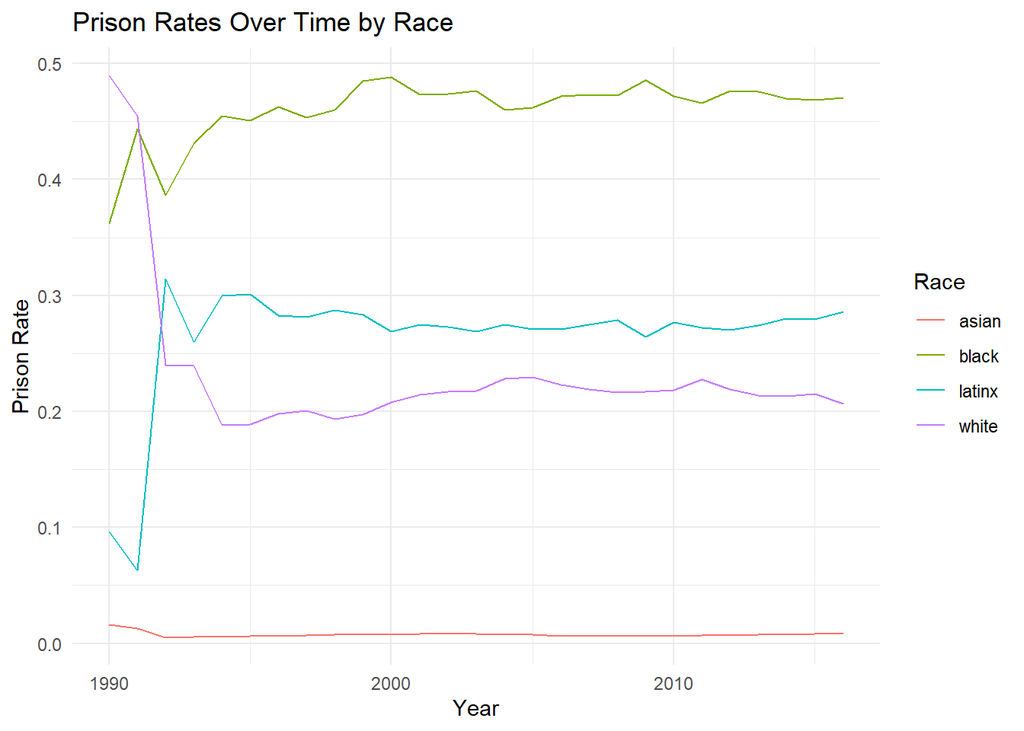

```r
source("Chart1_over_time.R")
```

### Variable Comparison Chart

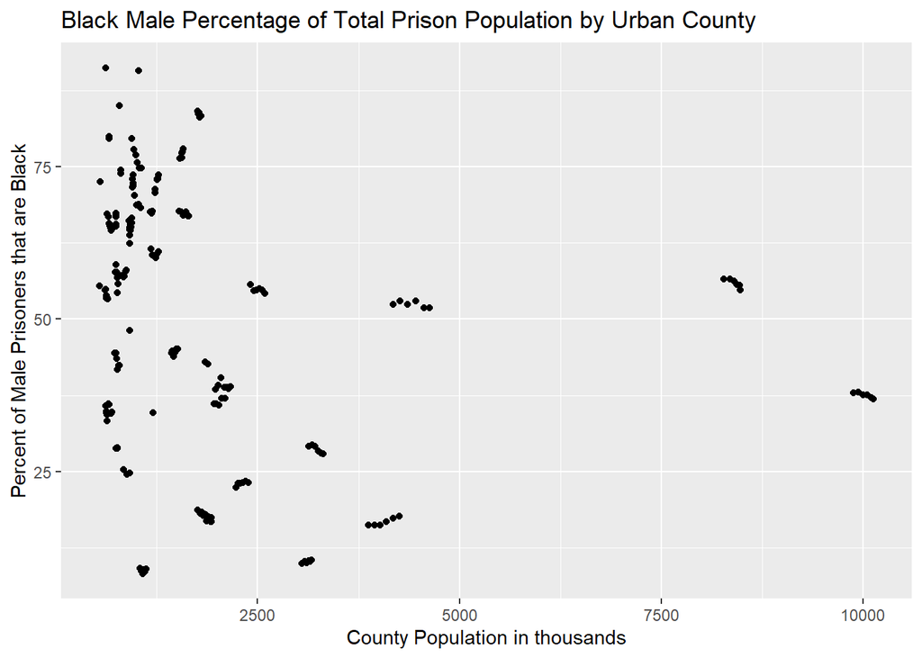

```r
source("Chart2_two_variables.R")
```

### Map

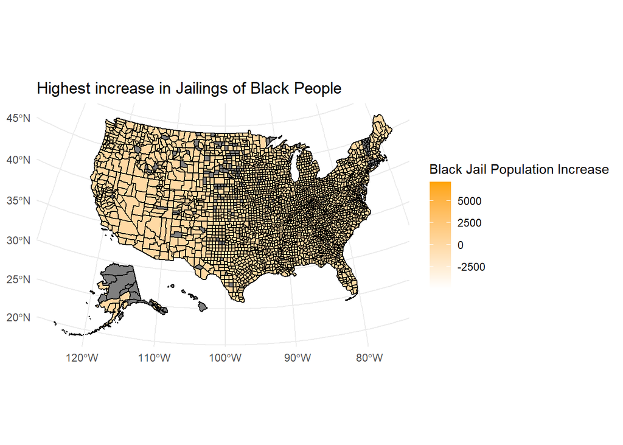

```r
source("US_map_plot.R")
```